# Lab 4. Elevation and topography

The shapes of mountains, slope, and topographic aspect

Author

Travis Belote

# Elevation and topography

Elevation, topography, and soils all govern patterns of landscapes and set the stage for physical and biological processes. Variability in topography influences physical processes like erosion, disturbance processes like fire, and micro-climatic conditions and associated distributions of resource availability like soil moisture. Elevation, topography, and soils form the landscape “template” upon which other physical and biological processes operate to give rise to landscape patterns of vegetation.

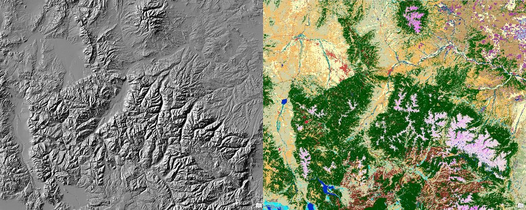

A shaded relief map shows the topographic patterns of the northern Greater Yellowstone Ecosystem and associated patterns in land cover.

In this lab, we are going to (1) examine the “shapes of mountains” in Montana and discuss the implications of these patterns on mountain ecosystems, and (2) use a digital elevation model (i.e., a raster map of elevation) to calculate various metrics like slope, aspect, topographic position, and a heat load index. Finally, we will explore interactions between elevation, heat load index, and other ecological patterns.

# Exercise 1. Shapes of mountains in Montana

Elevation (i.e., the vertical height of a landform or location) is associated with numerous factors - most notably temperature - influencing patterns of ecosystems. Temperature tends to decrease with increasing elevation. Temperature tends to decrease with increasing latitude too, of course. Ecosystems are therefore distributed such that an observer climbing a mountain can “sample” vegetation types observed at higher latitudes.

The role mountains play in facilitating or impeding species migrations during periods of historical changes in climate is the topic of some very interesting research. Likewise, research on the effects of future climate change on mountain ecosystems and their species has resulted in some fascinating insights. The general prediction is that species will move upslope to track increases in temperature. Using future climate predictions, some scientists have documented a potential loss of climate conditions at the tops of mountains. Other ecologists have measured the change in the geographic area of climate conditions to predict local extinctions of species. This work relies on a simple species-area relationship to predict loss in species with the loss in area as climate shifts up slopes. Notice the shape of the mountain in this classic example. There’s more land area in the lower elevation range and less area as you increase elevation.

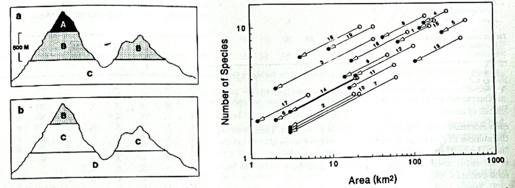

Kelly McDonald and Jim Brown’s 1992 paper investigated how a change in area of climate conditions with increasing temperature and upslope shifts could result in a decrease in species, relying on species-area relationships.

Paul Elsen and Morgan Tingley realized that not all mountains are shaped like this. They used data from a digital elevation model (DEM, a raster map where each pixel represents the elevation) to investigate the shapes of mountains simply by plotting histograms of elevation among mountain ranges around the planet. They used some summary statistics of the shape of each histogram to classify the shapes of mountains. Elsen and Tingley suggested that these different shapes of mountains warranted a more complicated view of how climate change may put mountain species at risk of losing habitat. Some mountains have more area at higher elevation providing more opportunities for species to find new habitat as temperatures increase.

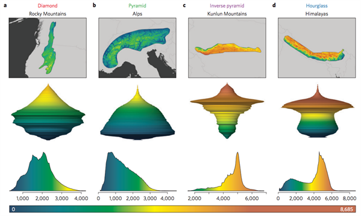

We are going to be be looking at the shapes of mountain ranges in Montana using the first step in Elsen et al.’s approach.

## Elevation and mountains

First, we will load libraries and bring in a [DEM](https://landfire.gov/topographic/elevation) and shapefile of [mountain ranges in Montana](https://mslservices.mt.gov/Geographic_Information/Data/DataList/datalist_Details.aspx?did=%7B03903E60-C81D-4126-A060-69AD917106B4%7D). You can read more about the datasets in the links.

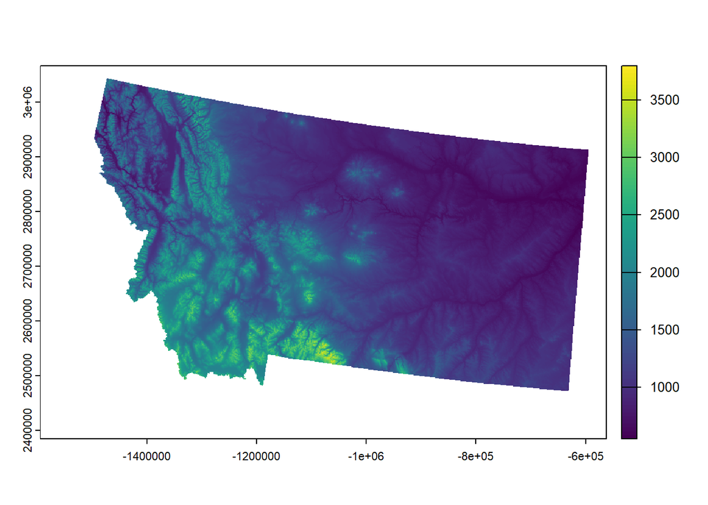

```r
library(terra)
library(sf)
library(tidyverse)
elev   <- rast("C:/Users/travi/TWS Dropbox/Travis Belote/BIOE515_LandEcol_Man_Fall2025/Labs/Lab 4/MT_dem.tif")

mtns <- vect("C:/Users/travi/TWS Dropbox/Travis Belote/BIOE515_LandEcol_Man_Fall2025/Labs/Lab 4/Mtn_Ranges")

# We need to project the mountains to the same crs as the elevation data
mtnsPRJ <- project(mtns, elev)

# Now, plot the maps of elevation and the Montana mountains
plot(elev)
```

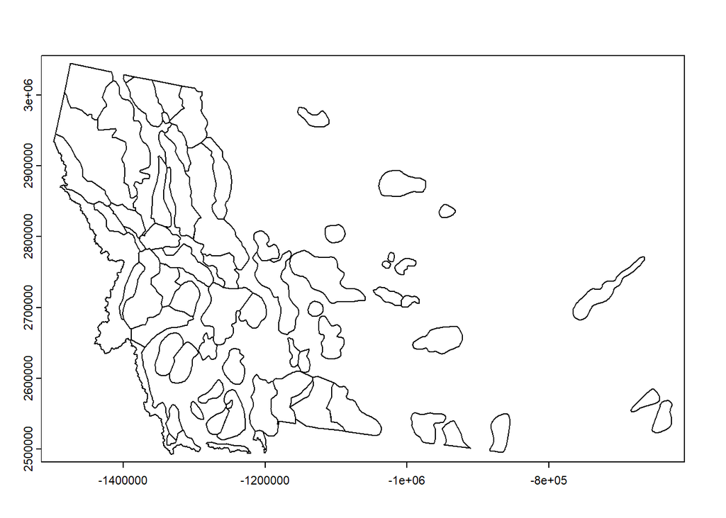

```r
plot(mtnsPRJ) # if this returns an error, remove "add = T" and rerun
```

We want to use tidyverse function to subset the mountains data (i.e., select only one mountain range). This works best if we turn the terra vector into an special features (sf) object. We’ll do that, then look at the names of the variables in the attribute table. “NAME” is one of the attributes, which stores the name of each mountain range. We’ll also look at all the mountain ranges in the dataset using `unique()`.

```r
# turn the terra vector into a sf object
mtns_sf <- st_as_sf(mtnsPRJ)

# what are the names of the variables in the attribute table?
names(mtns_sf)
```

```
[1] "Num"        "NAME"       "Num_Name"   "GNIS_ID"    "BGNDescrip"
[6] "Comment"    "geometry"
```

```r
# In the variable called "NAME" list the unique names
unique(mtns_sf$NAME)
```

```
 [1] "Purcell Mountains"            "Whitefish Range"
 [3] "Sweet Grass Hills"            "Apgar Mountains"
 [5] "Swan Range"                   "Bears Paw Mountains"
 [7] "Mission Range"                "Little Rocky Mountains"
 [9] "Big Sheep Mountains"          "Bitterroot Mountains"
[11] "Highwood Mountains"           "Reservation Divide"
[13] "Ninemile Divide"              "Adel Mountains"
[15] "North Moccasin Mountains"     "Rattlesnake Mountains"
[17] "Judith Mountains"             "Big Belt Mountains"
[19] "Little Belt Mountains"        "South Moccasin Mountains"
[21] "Garnet Range"                 "Big Snowy Mountains"
[23] "Little Snowy Mountains"       "John Long Mountains"
[25] "Castle Mountains"             "Elkhorn Mountains"
[27] "Crazy Mountains"              "Bridger Range"
[29] "Long Pines - Sheep Mountain"  "Bangtail Range"
```

[output cut: 18 more lines]

How many mountain ranges are there?

Now, we will use the `filter` function in `dplyr`, which is part of the `tidyverse` to select the Gallatin Range, which is just south of Bozeman. Then, plot the boundaries of this mountain range.

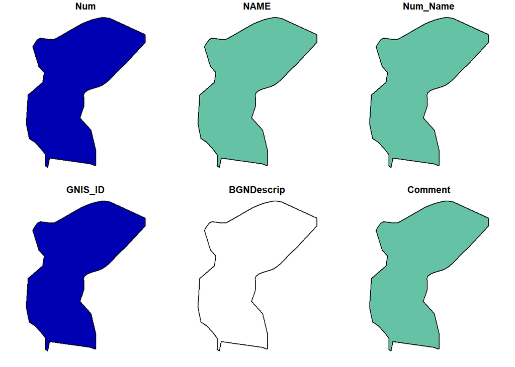

```r
gallatin_sf <- mtns_sf %>% filter(NAME == "Gallatin Range")
plot(gallatin_sf)
```

Next, we will use this new sf object as a `mask` to extract the DEM data for only the Gallatin Range. We add `trim()` to remove all the blank space left over after essentially clipping the data to the Gallatin Range. You can try removing `%>% trim()`, running that line, and plotting to see what `trim()` does. It can be handy.

```r
gallatin_elev <- elev %>% mask(gallatin_sf) %>% trim()
```

```
|---------|---------|---------|---------|
=========================================


|---------|---------|---------|---------|
=========================================
```

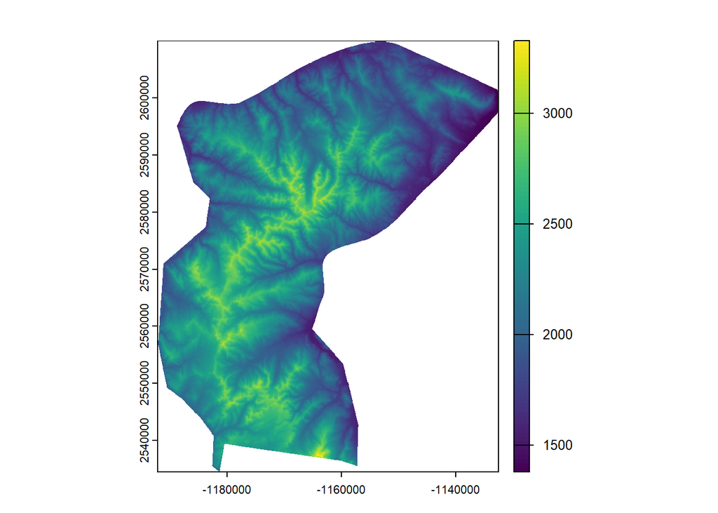

```r
plot(gallatin_elev)
```

One of the core parts of Elsen and Tingley’s method is to plot and examine the histograms of elevation for mountain ranges. We will do this with `hist()`, which plots a traditional histogram where the number of observations (pixels) within each bin (a range of values) is plotted. We will also use `density()` to plot a smoothed histogram ([a kernel density plot](https://www.r-bloggers.com/2023/08/kernel-density-plots-in-r/)).

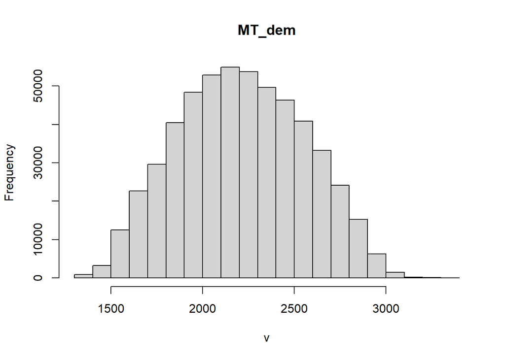

```r
hist(gallatin_elev)
```

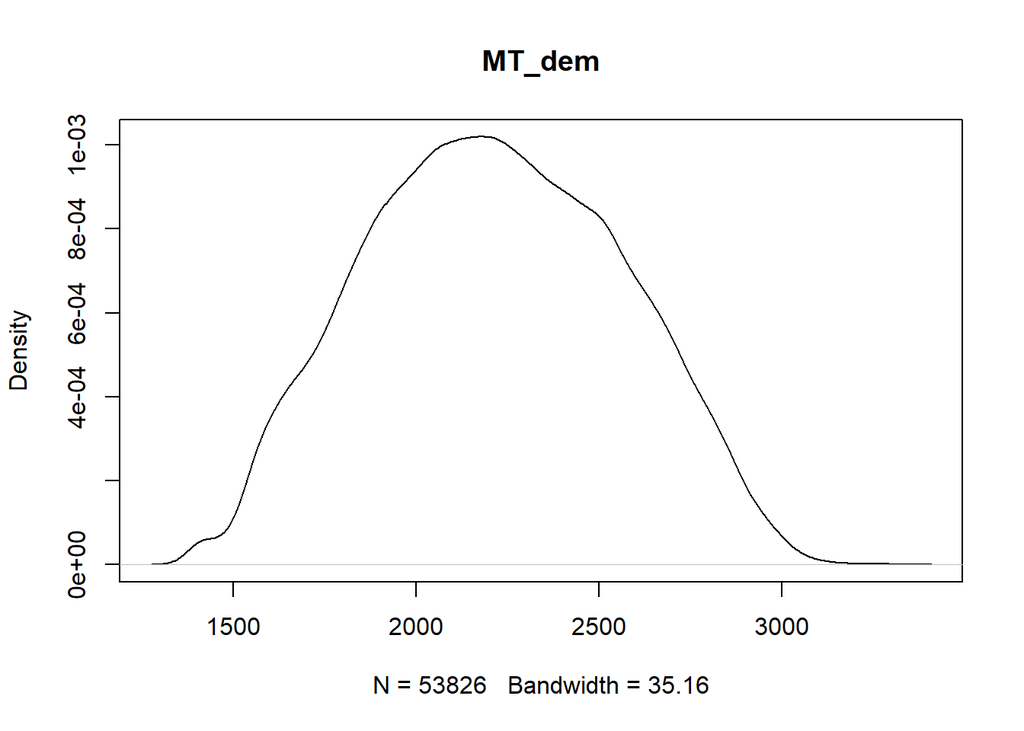

```r
density(gallatin_elev)
```

One way Elsen and Tingley plotted the land area for different elevations was to create a two-sided kernel density plot. You can do this in R using [violin plots](https://mode.com/blog/violin-plot-examples), which are becoming more common in the scientific literature (but, beware, some people do not like these plots!).

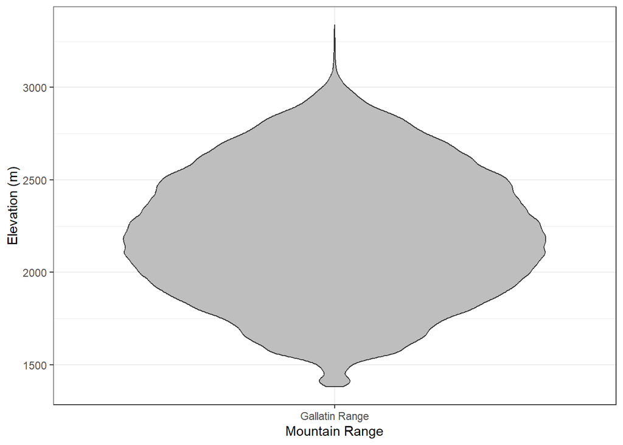

```r
gallatin_elev %>%
  as.data.frame() %>%
  ggplot(aes(x = "Gallatin Range", y = MT_dem)) +
  geom_violin(scale = "width", fill = "grey")  +
  labs(x = "Mountain Range", y = "Elevation (m)") +
  theme_bw()
```

What do you notice about the “shape” of the Gallatin Range in relation to the different categories of mountain shapes that Elsen and Tingley recognized? We won’t use their method to classify mountain ranges into the categories (diamond, pyramid, inverse pyramid, hourglass). Instead, just “eye-ball” the shape and list the shape you think it bests matches.

**Task 1.**

Choose 2 other mountain ranges in Montana, follow the steps above to extract the data to the mountain ranges of your choice, plot the histogram and density plot of elevation, and describe which shape you think it most matches of the four recognized by Elsen and Tingley. Describe the possible implications of these shapes. Write up an abstract following *Landscape Ecology* abstract format.

**OPTIONAL. Histograms as map legends.**

I have found that histograms serve as excellent map legends. This is a very informative way to visualize the spatial patterns and statistical distribution simultaneously and provides transparency in how colors are assigned given the range of values in a raster dataset. In the case at hand, mapping elevation alongside the histogram in a color-coordinated way can provide a really information-rich visualization of data.

I start by creating a color ramp that attempts to match Elsen and Tingley. I then turn the DEM raster into a dataframe so that I can plot it using ggplot. I then use the density function to pull out values from the kernel density estimation for plotting in ggplot. Finally, I put the map and histogram together using the `patchwork` library.

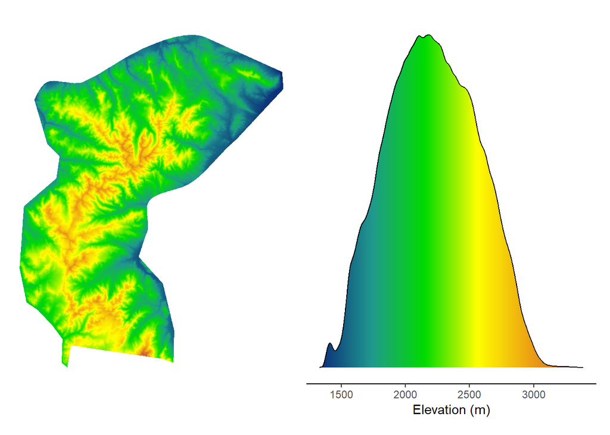

```r
## OPTIONAL!

# Custom ramp based on your bar
paul_colors <- c("#0B2C7A", "#20998F", "#00DB00", "#FFFF00", "#EDA113", "#C2523C")
paul_ramp <- colorRampPalette(paul_colors)(100)

# Extract elevation values from DEM (sample if very large)
elev_df <- as.data.frame(gallatin_elev, xy = TRUE, na.rm = TRUE)
names(elev_df) <- c("x", "y", "elevation")

map <- elev_df %>% ggplot() +
  geom_tile(aes(x = x, y = y, fill = elevation)) +
  scale_fill_gradientn(colors = paul_ramp) +
  coord_fixed() +
  theme_void() +
  theme(legend.position = "none")

# Compute density of elevations
dens <- density(elev_df$elevation, na.rm = TRUE, n = 2^12)

# Convert to a dataframe for ggplot
dens_df <- data.frame(
  elevation = dens$x,
  density   = dens$y)

hist <- ggplot(dens_df, aes(x = elevation, y = density)) +
  geom_segment(aes(xend = elevation, yend = 0, colour = elevation)) +
  geom_line(color = "black", linewidth = 0.5) +
  scale_colour_gradientn(colours = paul_ramp) +
  theme_classic() +
  labs(x = "Elevation (m)", y = NULL) +
  theme(legend.position = "none",
    axis.text.y = element_blank(),
    axis.ticks.y = element_blank(),
    axis.line.y = element_blank())

# patchwork is a package that allows you to easily put multiple
# ggplot maps together in panels.
#install.packages("patchwork")
library(patchwork)
map + hist
```

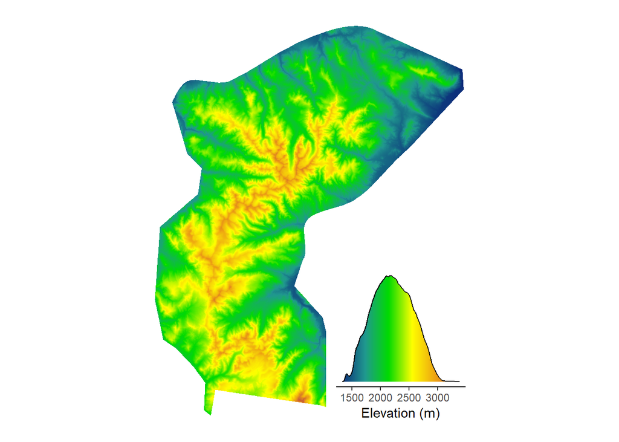

```r
final_plot <- map + inset_element(hist,
  left   = 0.55,
  bottom = 0.02,
  right  = 0.98,
  top    = 0.40,
  align_to = 'panel')

final_plot
```

# Exercise 2. Topography (slope and aspect) and “heat load index”

Now, we will focus again on the Gallatin Range and use the DEM to calculate slope (the steepness of the topography), aspect (the direction the slope faces), and several derived metrics intended to represent topographic position and “heat load”. These variables (elevation, slope, aspect, of heat load) could be useful covariates in models of seedling success, species distributions, predictors of fire severity, etc.

Slope refers to how steepness of the area (change in elevation with change in distance), whereas aspect refers to the compass direction a slope faces. In the northern hemisphere at mid-latitudes steep slopes that face southwest are much hotter and drier than steep slopes that face northeast. This fact influences soil moisture, vegetation productivity, species composition, fuel moisture and fire behavior, snow depth, and more. The same principles apply to a built environment: the slope (pitch) and aspect of your home’s roof determines the optimal locations of solar panel installation and your risk of developing ice dams. This information can help you predict skiing conditions too. Slopes with southerly aspects tend to warm in the day and - of course - freeze at night. This can lead to really icy conditions in the morning and “mashed potatoes” in the afternoon.

Notice the striking differences in vegetation composition and structure related to aspect in this photo from southwestern Idaho.

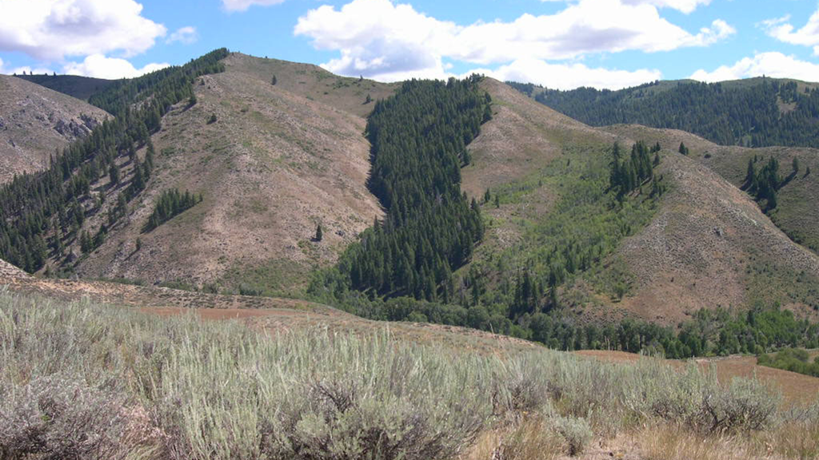

Photo credit: Thayne Tuason

We will start by looking - again - at the elevation of the Gallatin Range, then calculating the slope and aspect using `terra::terrain()`, which include a variety of topographic calculations. The default units for slope are degrees (0 = flat and 90 = vertical cliff), but there’s some confusing information about this online. I found one page that suggested that radians are the default units. You can check this by running `terrain(gallatin_elev, "slope")` and compare the values when you add `, unit = "radians"` to the line of code. The default units for aspect are in degrees (the compass baring that the slope faces). You can also use radians for aspect too.

```r
# recall that we extracted (clipped) the DEM data to the Gallatin Range
# above.
gallatin_elev <- elev %>% mask(gallatin_sf) %>% trim()
```

```
|---------|---------|---------|---------|
=========================================


|---------|---------|---------|---------|
=========================================
```

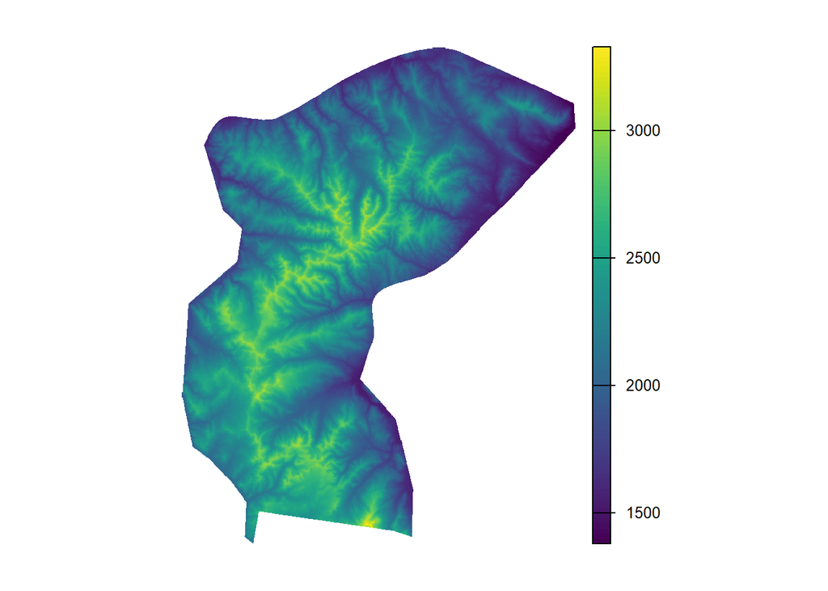

```r
plot(gallatin_elev, axes = F) # plot the DEM without axes
```

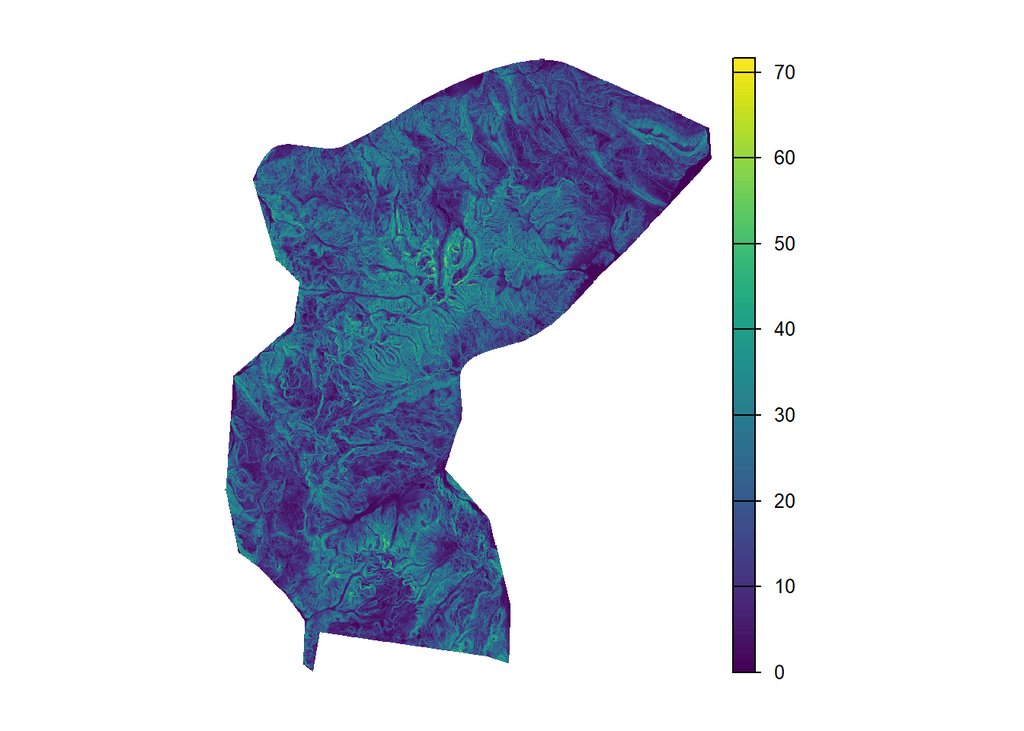

```r
# calculate slope
slope <- terrain(gallatin_elev, "slope") # try also with: unit = "radians"
slopeRad <- terrain(gallatin_elev, "slope", unit = "radians")

# Look at the maps of the estimates of slope using the different units
plot(slope, axes = F)
```

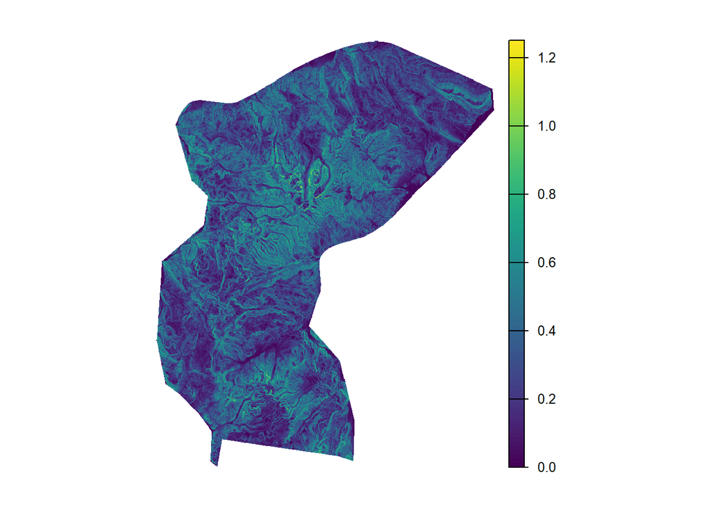

```r
plot(slopeRad, axes = F)
```

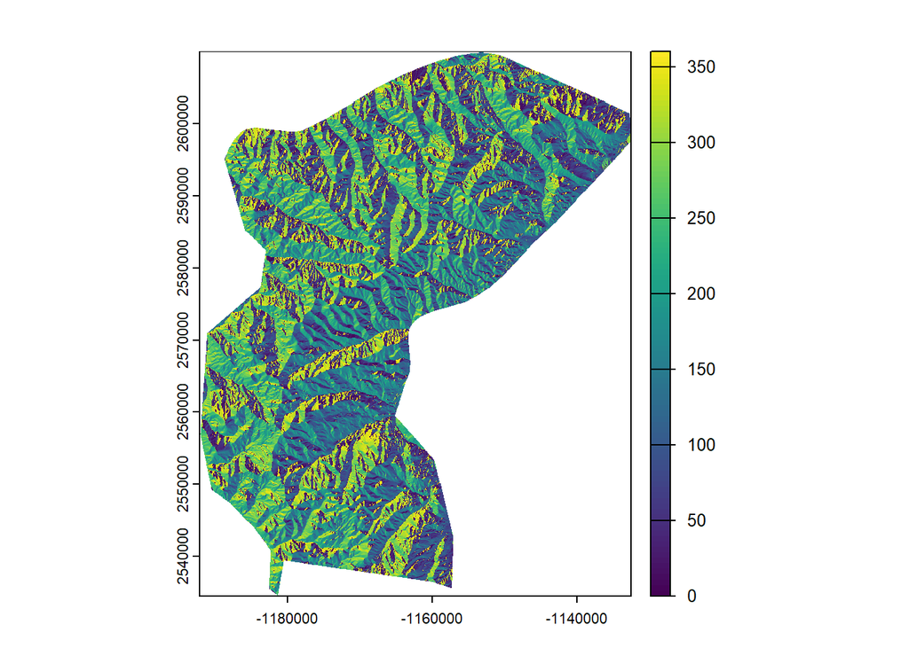

```r
# Calculate aspect with both units and plot them both
aspect    <- terrain(gallatin_elev, "aspect")
aspectRad <- terrain(gallatin_elev, "aspect", unit = "radians")

plot(aspect)
```

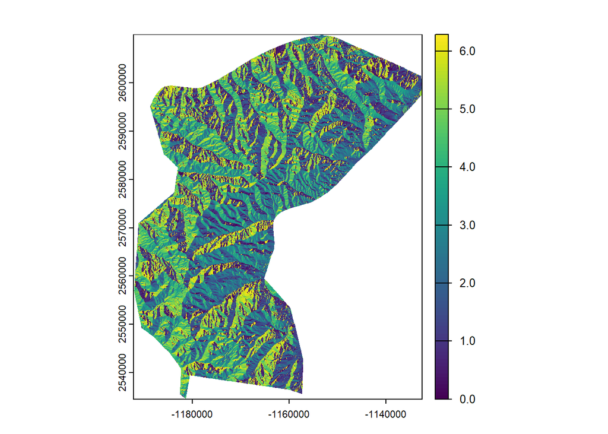

```r
plot(aspectRad)
```

Slope and aspect can be very useful by themselves to understand the physical template governing landscape composition and arrangement. However, consider that aspect of a slope is basically the direction that the slope faces. If you collect these data in the field, you will often use a compass to measure which way the slope faces (see cartoon below, [source](https://www.attheedgemountaineering.co.uk/post/navigation-techniques-advanced-compass-techniques)).

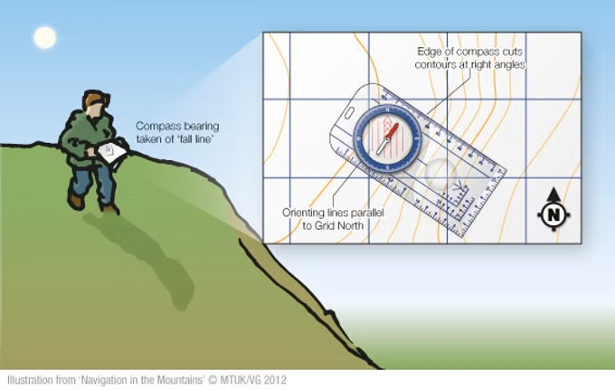

A slope that is facing one degree west of due north is 359 degrees, and a slope facing 1 degree east of due north is 1 degree (obviously). If you are not familiar with using a compass look at how the directions are distributed below ([source](https://en.wikibooks.org/wiki/Trigonometry/Compass_Bearings)). This presents a challenge when using aspect as a variable.

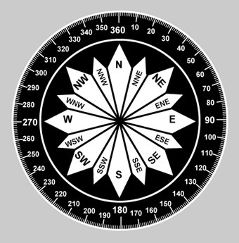

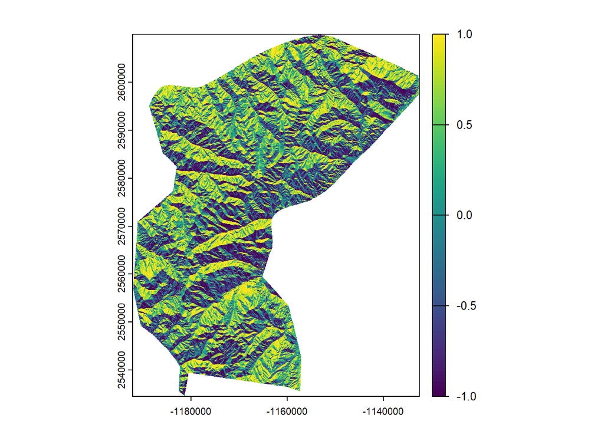

```r
cos_aspect <- cos(aspectRad)
plot(cos_aspect)
```

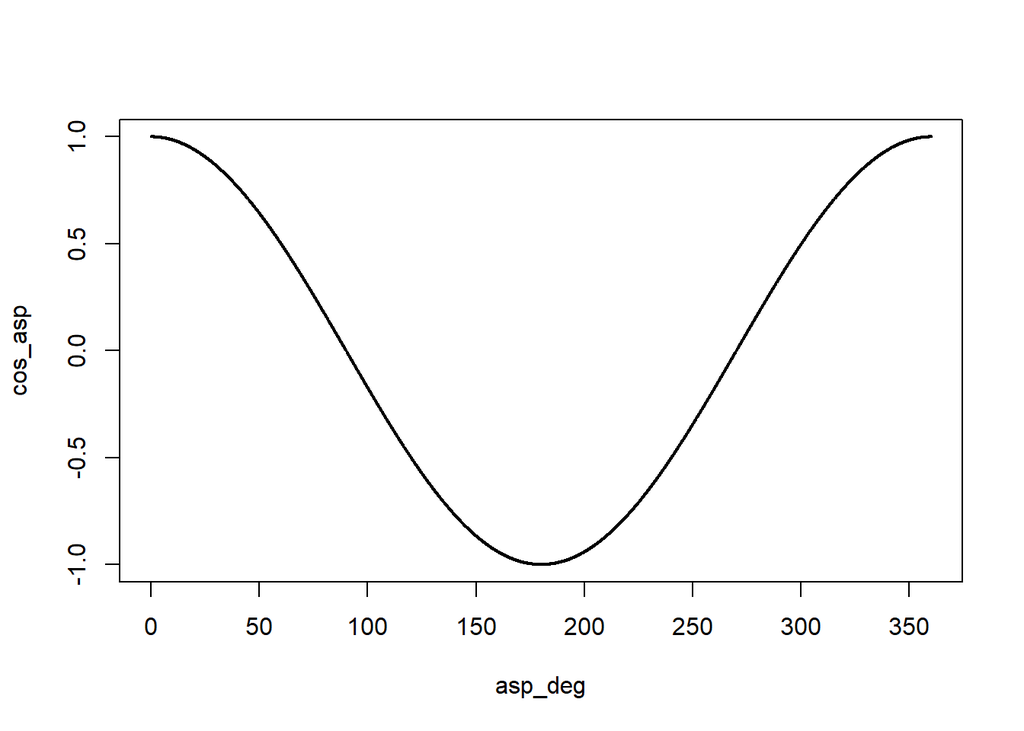

```r
# Let's stack aspect (in degrees), aspect in radians, and the cosine
# of aspect
aspects <- c(aspect, aspectRad, cos_aspect)

# make sure you change the names of the layers in the stack
names(aspects) <- c("asp_deg", "asp_rad", "cos_asp")

# look at the plot of aspects in degrees (compass bearing) with the cosine
# of aspect in radians

plot(aspects$asp_deg, aspects$cos_asp)
```

Taking the cosine of aspect takes care of the issue that 359 and 1 are very different numerically but very similar ecologically. But, there are still two issues to consider. Slopes facing due south actually aren’t as hot and dry as those facing slightly southwest. This is because southwestern slopes in the northern hemisphere receive afternoon sun. These slopes have had all day to warm up and experience evaporative cooling. Southeastern facing slopes will received the amount of incoming solar radiation as southwestern slopes, but southeastern slopes received their sun in the morning when conditions are cooler. One way to deal with this - proposed by [McCune and Dylan 2002](https://onlinelibrary.wiley.com/doi/epdf/10.1111/j.1654-1103.2002.tb02087.x) - is to adjust the cosine so that southwestern slopes are assigned the highest value and northeastern slopes the lowest values. We can use the first formula in McCune and Dylan (2002) with our calculated aspect for the Gallatin Range.

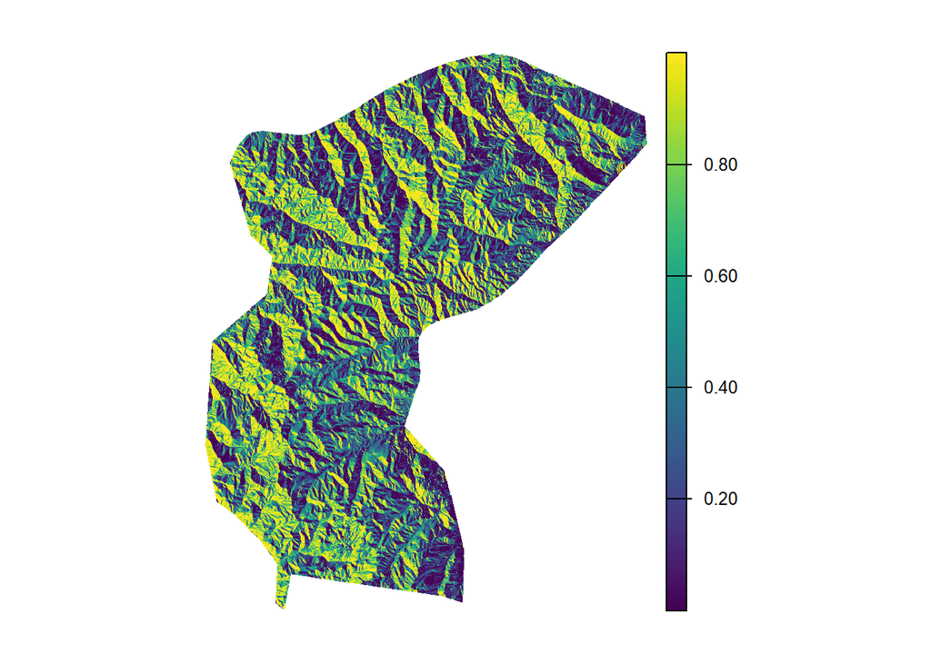

```r
# Use first formula in McCune and Dylan (2002) to calculate a heat load index # This shifts the index so that that southwestern slopes (facing 225 degrees)
# are highest and northeastern slopes (facing 45 degrees) have the
# lowest value.

hli_1 <- (1 - cos(aspectRad - 45))/2
plot(hli_1, axes = F)
```

McCune and Dylan (2002) recognize that this heat load index doesn’t account for the steepness of slopes. The aspect direction will be more important on steeper slopes. Luckily, the `spatialEcol` package includes a heat load index that accounts for the fact that steep southwestern-facing slopes tend to be the hottest and driest topographic aspects in mid-latitudes of the northern hemisphere. You also use the elevation data as input and the package calculates slope and aspect “behind the scenes”.

```r
# first download the spatialEcol package (remove the #) and load it
# install.packages("spatialEcol")
library(spatialEco)
hli_2 <- spatialEco::hli(gallatin_elev)
```

```
Using folded aspect equation for Northern hemisphere
```

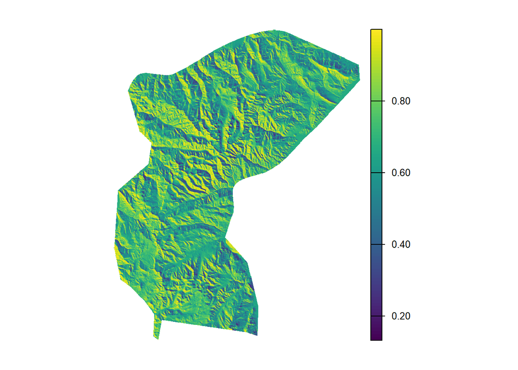

```r
plot(hli_2, axes = F)
```

Another handy metric in `spatialEco` is a topographic position index. Because water, sediments, carbon, and other materials flow or fall downhill, we often want to estimate where a location (pixel) is in relation to other locations. A topographic index can measure the relative position of locations using multiple spatial extents. Some locations can be locally “low” but more regionally “high”. Think about an alpine lake that drains the highest mountains. This hypothetical lake is low compared to the surrounding mountains but relatively high compared to other streams and lakes in a mountain range. The topographic position index (`tpi`) allows you to specify what extent you want to measure it. TPI is the value of the focal pixel minus the average of the values in the moving window. We will run it for different moving window sizes and plot the results.

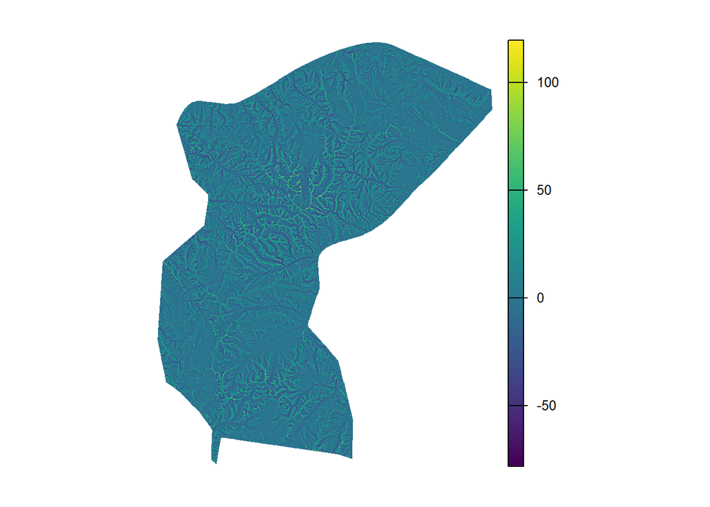

```r
# run TPI with scale = 13 (i.e., 13x13 window or 6 pixels on each
# side of the center, focal pixel)
tpi13 <- spatialEco::tpi(gallatin_elev, scale = 13)
plot(tpi13, axes = F)
```

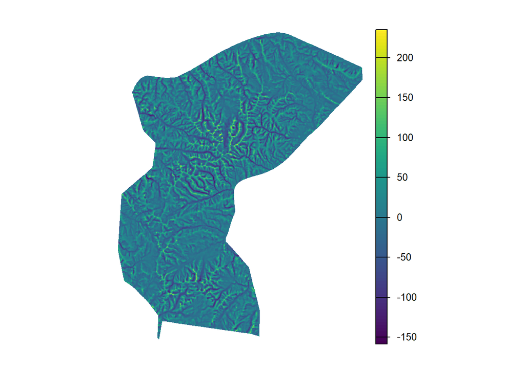

```r
# run TPI with scale = 33 (i.e., 33x33 window or 16 pixels on each
# side of the center pixel)
tpi33 <- spatialEco::tpi(gallatin_elev, scale = 33)
plot(tpi33, axes = F)
```

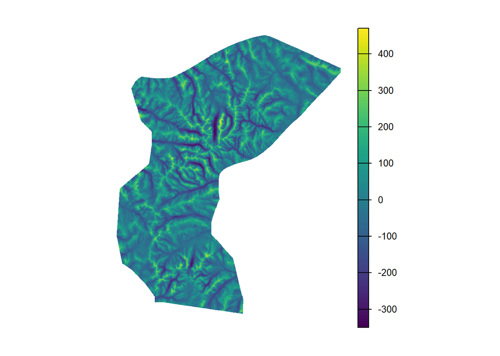

```r
# run TPI with scale = 101 (i.e., 101x101 windw or 50 pixels on each
# side of the center pixel)
tpi101 <- tpi(gallatin_elev, scale = 101)
plot(tpi101, axes = F)
```

Notice how the patterns and values change with the different moving window sizes? How might you use this metric in ecological research?

## Heat load index and canopy cover.

Now, let’s investigate the relationship between ecological variables and topography. Specifically, we will start by evaluating the relationship between canopy cover and heat load index and whether this relationship varies at different elevations. You can find more information on the canopy cover dataset [here](https://data.fs.usda.gov/geodata/rastergateway/treecanopycover/docs/TCC_v2023-5_Methods.pdf). Briefly, for this dataset canopy cover is the % of an area covered by tree canopies. Canopy cover is a continuous datasets that tells us how how dense the forest canopy is across the landscape. This datasets could be used to model species habitat suitability (differentiating between species that require or avoid closed canopy forests), as an input to connectivity modeling, to assess the continuity of fuels for wildfire risk assessment, etc. Here, we’re interested in how canopy cover varies with heat load index (a function of slope and aspect). Before running the analysis, what do you predict the relationship to be between heat load index and canopy cover in the Gallatin Range south of Bozeman? How might this relationship change with elevation in the Gallatin Range?

Bring in the canopy cover data and “clip” it to the Gallatin Range as we used in the previous exercise. Use `trim()` to remove empty space around your new raster. We will then stack elevation, canopy cover, and heat load index into a raster stack, rename the variables, turn the stack into a dataframe, and plot the relationship between heat load index and canopy cover.

```r
# bring in data on elevation and mountains and project again if you need to

# bring in data on canopy cover (I've already projected it for you)
canopy <- rast("C:/Users/travi/TWS Dropbox/Travis Belote/BIOE515_LandEcol_Man_Fall2025/Labs/Lab 4/MT_canopy_coverPRJ.tif")

# extract the canopy cover to the gallatin range
gallatin_canopy <- canopy %>% mask(gallatin_sf) %>% trim()
```

```
|---------|---------|---------|---------|
=========================================


|---------|---------|---------|---------|
=========================================
```

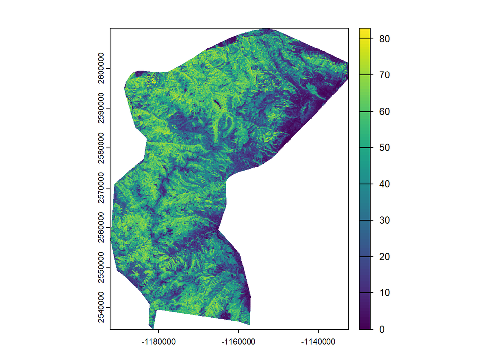

```r
plot(gallatin_canopy)
```

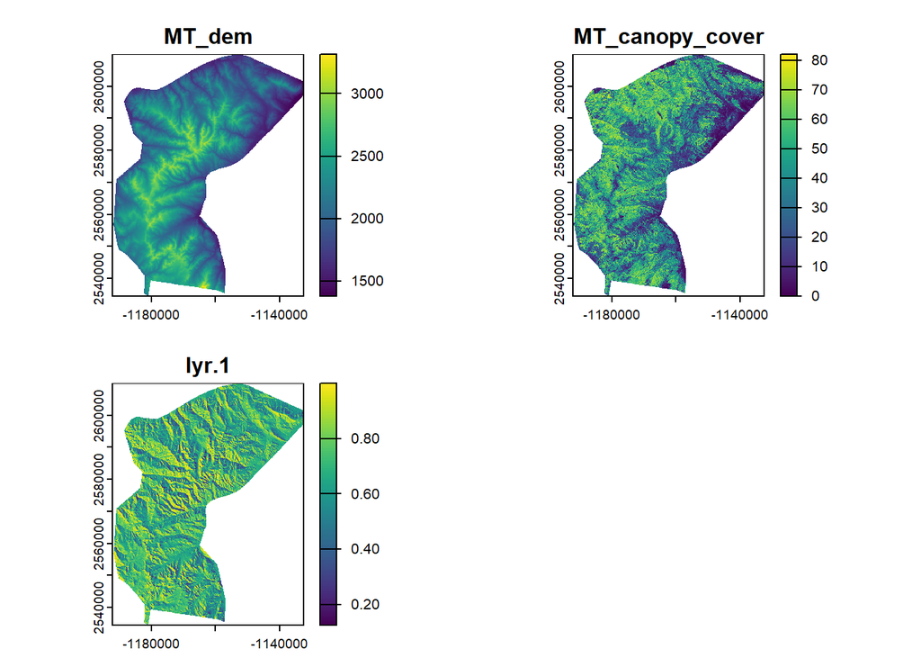

```r
# stack the variables into a raster stack called canopy_hli and
# plot the stack
canopy_hli <- c(gallatin_elev, gallatin_canopy, hli_2)
plot(canopy_hli)
```

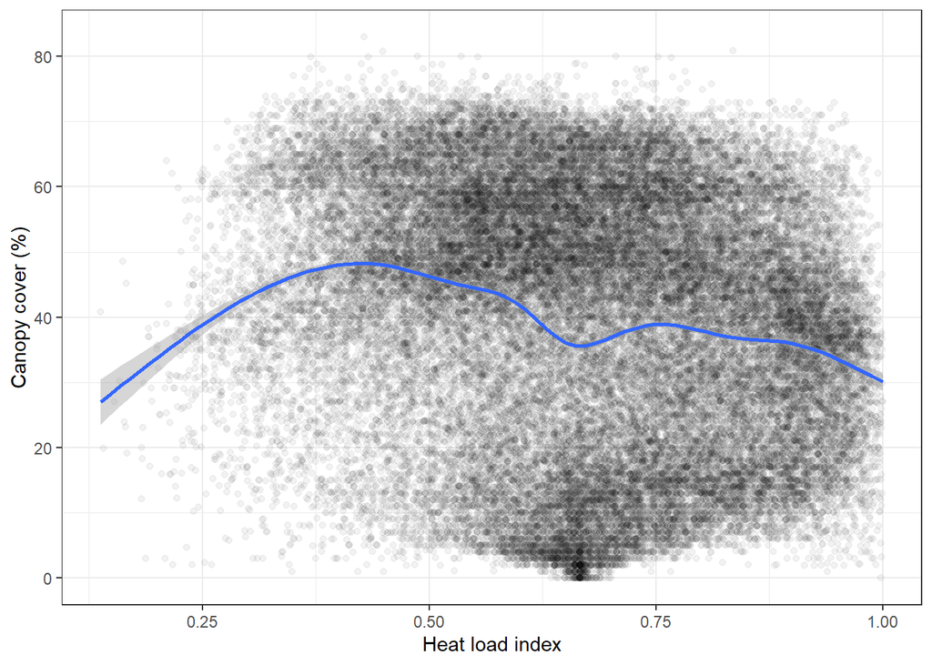

```r
# I recommend renaming layers in a stack at this stage
names(canopy_hli) <- c("elevation", "canopy_cover", "heat_load_index")

# turn into a dataframe
df_canopy_hli <- canopy_hli %>% as.data.frame()

# plot the relationship between heat load index and canopy cover
# we will add a GAM (generalized additive model) smoothing function
# to explore the relationship
df_canopy_hli %>% sample_n(50000) %>%
  drop_na() %>%
  ggplot(aes(heat_load_index, canopy_cover)) +
  geom_point(alpha = 0.05) +
  geom_smooth(stat = "smooth", method = "gam") +
  xlab("Heat load index") + ylab("Canopy cover (%)") +
  theme_bw()
```

Recall that we’re interested in how this relationships varies from low to high elevations. We’re first going to classify elevation to 2 “bins” using `ntile(2)` whereby half of the elevation values get assigned a 1 (lower elevation) and half get assigned a 2 (higher elevation). We will then use these new elevation classes to plot the relationship of heat load index and canopy cover within low and high elevations.

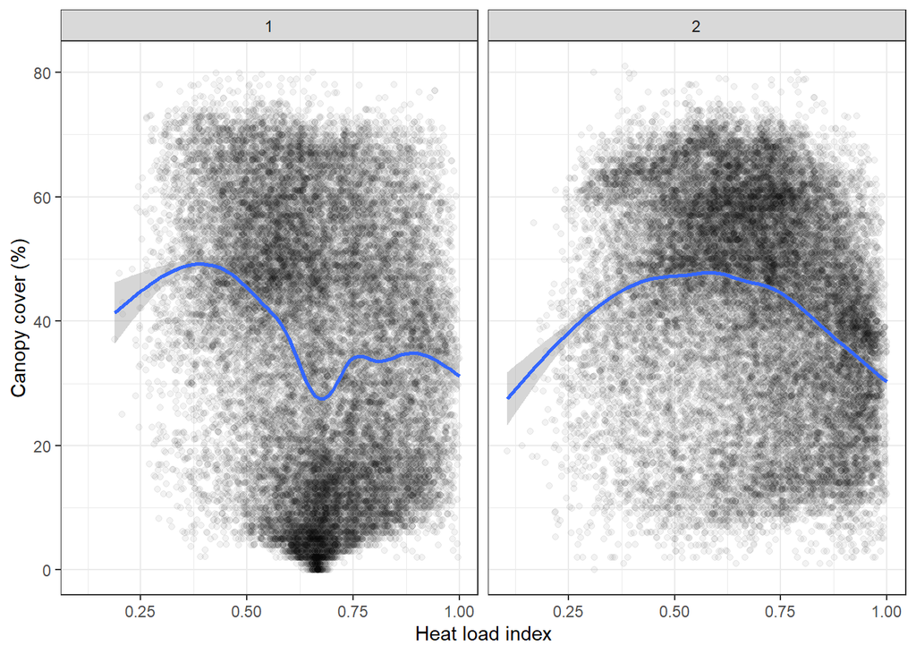

```r
# Classify elevation into 2 equal sized groups
df_canopy_hli <- df_canopy_hli %>% mutate(elev_bin = ntile(elevation, 2))

df_canopy_hli %>% sample_n(50000) %>% # take a sample for faster plotting
  drop_na() %>%  # remove any NAs in the data
  ggplot(aes(heat_load_index, canopy_cover)) +
  geom_point(alpha = 0.05) + # make the symbols semi-transparent using alpha
  facet_wrap(~elev_bin) + # split the data into panels for the elevation bins
  geom_smooth(stat = "smooth", method = "gam") + # add GAM smooth line
  xlab("Heat load index") + ylab("Canopy cover (%)") + # customize axis labels
  theme_bw() # use as black and white (bw) theme
```

Look at this plot. Are you convinced that relationships exist between heat load index and canopy cover? How does the relationship change with elevation? Try to explain the patterns. Why would heat load be associated with canopy cover? What other factors affect canopy cover other than slope and aspect?

**Task 2.**

Re-run the analysis above for another mountain range in Montana, compare with the patterns we observed in the Gallatin Range, and write up an abstract following *Landscape Ecology* abstract format.